# Análisis exploratorio: retail Falabella / Éxito

# Objetivo

Preprocesamiento (duplicados estructurales e imputación por media), análisis descriptivo y comparación de correlaciones de Pearson y Spearman sobre ventas mensuales agregadas (Falabella / Éxito). No hay identificador de cliente. No se ajusta un modelo predictivo.

El archivo `data/retail.csv` incluido en este repositorio es una **muestra sintética reproducible** (`set.seed(42)`), no ventas reales de Falabella o Éxito; puede sustituirse por el insumo auténtico con las mismas 7 columnas del diccionario.

# Carga y tipos de columna

Los tipos se reportan **antes** de eliminar duplicados estructurales.

```r
csv_path <- "data/retail.csv"
if (!file.exists(csv_path)) {
  stop("No existe data/retail.csv. Coloca el insumo en esa ruta.")
}
retail_raw <- readr::read_csv(csv_path, show_col_types = FALSE)
missing_cols <- setdiff(required_cols, names(retail_raw))
if (length(missing_cols) > 0) {
  stop(
    "Faltan columnas del diccionario: ",
    paste(missing_cols, collapse = ", ")
  )
}
retail_raw <- dplyr::select(retail_raw, dplyr::all_of(required_cols))
```

```r
dplyr::glimpse(retail_raw)
```

```
## Rows: 97
## Columns: 7
## $ mes                     <chr> "2024-01", "2024-01", "2024-01", "2024-01", "2…
## $ ciudad                  <chr> "Bogotá", "Bogotá", "Bogotá", "Bogotá", "Medel…
## $ categoria               <chr> "Ropa", "Hogar", "Tecnología", "Alimentos", "R…
## $ ventas_totales_millones <dbl> 418.48, 426.72, 185.87, 387.27, 317.45, 272.07…
## $ ticket_promedio         <dbl> 76626, 104835, 140316, 120970, 122068, 58659, …
## $ unidades_vendidas       <dbl> 1379, 1381, 949, 804, 4442, 1254, 6048, 5958, …
## $ num_transacciones       <dbl> 1830, 342, 4363, 3712, 1713, 2055, 1796, 631, …
```

```r
class_tbl <- tibble::tibble(
  columna = names(retail_raw),
  clase = vapply(retail_raw, function(x) paste(class(x), collapse = ", "), character(1))
)
class_tbl
```

| columna | clase |
| --- | --- |
| mes | character |
| ciudad | character |
| categoria | character |
| ventas_totales_millones | numeric |
| ticket_promedio | numeric |
| unidades_vendidas | numeric |
| num_transacciones | numeric |

```r
na_before <- colSums(is.na(retail_raw))
na_before
```

```
##                     mes                  ciudad               categoria
##                       0                       0                       0
## ventas_totales_millones         ticket_promedio       unidades_vendidas
##                       0                       4                       2
##       num_transacciones
##                       0
```

```r
n_ticket_na <- unname(na_before[["ticket_promedio"]])
n_unidades_na <- unname(na_before[["unidades_vendidas"]])
if (n_ticket_na != 4 || n_unidades_na != 2) {
  warning(
    "Se esperaban 4 NA en ticket_promedio y 2 en unidades_vendidas; ",
    "encontrados: ticket_promedio=", n_ticket_na,
    ", unidades_vendidas=", n_unidades_na,
    ". Se continúa."
  )
}
```

# Duplicados estructurales

Solo se eliminan filas idénticas en **todas** las columnas. No se de-duplica por `mes` ni por ninguna otra llave.

```r
n_raw <- nrow(retail_raw)
retail_dedup <- dplyr::distinct(retail_raw, .keep_all = TRUE)
n_dedup <- nrow(retail_dedup)
n_dropped_dups <- n_raw - n_dedup
if (n_dedup == 0) {
  stop("distinct() dejó 0 filas.")
}
cat("Filas originales:", n_raw, "\n")
```

```
## Filas originales: 97
```

```r
cat("Filas tras distinct():", n_dedup, "\n")
```

```
## Filas tras distinct(): 96
```

```r
cat("Filas duplicadas eliminadas:", n_dropped_dups, "\n")
```

```
## Filas duplicadas eliminadas: 1
```

```r
if (n_dropped_dups > 0) {
  warning("Se eliminaron ", n_dropped_dups, " fila(s) duplicadas por estructura.")
}
na_dedup <- colSums(is.na(retail_dedup))
na_dedup
```

```
##                     mes                  ciudad               categoria
##                       0                       0                       0
## ventas_totales_millones         ticket_promedio       unidades_vendidas
##                       0                       4                       2
##       num_transacciones
##                       0
```

```r
n_remaining_dups <- sum(duplicated(retail_dedup))
cat("Duplicados estructurales restantes:", n_remaining_dups, "\n")
```

```
## Duplicados estructurales restantes: 0
```

# Imputación y exportación

Media global, después de quitar duplicados, solo en `ticket_promedio` y `unidades_vendidas`.

```r
mean_ticket <- mean(retail_dedup$ticket_promedio, na.rm = TRUE)
mean_unidades <- mean(retail_dedup$unidades_vendidas, na.rm = TRUE)
retail_clean <- retail_dedup |>
  dplyr::mutate(
    ticket_promedio = tidyr::replace_na(ticket_promedio, mean_ticket),
    unidades_vendidas = tidyr::replace_na(unidades_vendidas, mean_unidades)
  )

if (any(is.na(retail_clean$ticket_promedio)) ||
    any(is.na(retail_clean$unidades_vendidas))) {
  stop("La imputación por media dejó NA en ticket_promedio o unidades_vendidas.")
}

if (inherits(retail_clean$mes, "Date")) {
  retail_clean$mes <- format(retail_clean$mes, "%Y-%m")
} else {
  retail_clean$mes <- as.character(retail_clean$mes)
}

retail_clean <- retail_clean |>
  dplyr::mutate(
    ciudad = factor(ciudad),
    categoria = factor(
      categoria,
      levels = c("Ropa", "Hogar", "Tecnología", "Alimentos")
    )
  )

cat("Filas post-imputación:", nrow(retail_clean), "\n")
```

```
## Filas post-imputación: 96
```

```r
print(colSums(is.na(retail_clean)))
```

```
##                     mes                  ciudad               categoria
##                       0                       0                       0
## ventas_totales_millones         ticket_promedio       unidades_vendidas
##                       0                       0                       0
##       num_transacciones
##                       0
```

```r
dir.create("data", showWarnings = FALSE)
retail_export <- retail_clean |>
  dplyr::mutate(
    ciudad = as.character(ciudad),
    categoria = as.character(categoria)
  ) |>
  dplyr::select(dplyr::all_of(required_cols))
readr::write_csv(retail_export, "data/retail_clean.csv")

stopifnot(file.exists("data/retail_clean.csv"))
exported <- readr::read_csv("data/retail_clean.csv", show_col_types = FALSE)
stopifnot(identical(names(exported), required_cols))
stopifnot(sum(is.na(dplyr::select(exported, dplyr::all_of(num_cols)))) == 0)
```

# Análisis descriptivo

Resúmenes sobre `retail_clean`. Los atípicos no se recortan.

```r
desc_num <- retail_clean |>
  dplyr::select(dplyr::all_of(num_cols)) |>
  tidyr::pivot_longer(dplyr::everything(), names_to = "variable", values_to = "valor") |>
  dplyr::group_by(variable) |>
  dplyr::summarise(
    n = dplyr::n(),
    media = mean(valor),
    mediana = median(valor),
    sd = sd(valor),
    min = min(valor),
    max = max(valor),
    iqr = IQR(valor),
    .groups = "drop"
  )
desc_num
```

| variable | n | media | mediana | sd | min | max | iqr |
| --- | --- | --- | --- | --- | --- | --- | --- |
| num_transacciones | 96 | 2511.6979 | 2323.000 | 1408.8740 | 211.00 | 4956.00 | 2177.25 |
| ticket_promedio | 96 | 110012.1739 | 114380.500 | 40611.9725 | 25214.00 | 174204.00 | 64421.75 |
| unidades_vendidas | 96 | 3744.0957 | 3744.096 | 2173.2818 | 533.00 | 7974.00 | 3068.50 |
| ventas_totales_millones | 96 | 273.6203 | 279.695 | 113.4525 | 80.09 | 445.89 | 194.74 |

```r
freq_ciudad <- retail_clean |>
  dplyr::count(ciudad, name = "n") |>
  dplyr::arrange(dplyr::desc(n))
freq_categoria <- retail_clean |>
  dplyr::count(categoria, name = "n") |>
  dplyr::arrange(dplyr::desc(n))
freq_mes <- retail_clean |>
  dplyr::count(mes, name = "n") |>
  dplyr::arrange(mes)
freq_ciudad
```

| ciudad | n |
| --- | --- |
| Barranquilla | 24 |
| Bogotá | 24 |
| Cali | 24 |
| Medellín | 24 |

```r
freq_categoria
```

| categoria | n |
| --- | --- |
| Ropa | 24 |
| Hogar | 24 |
| Tecnología | 24 |
| Alimentos | 24 |

```r
freq_mes
```

| mes | n |
| --- | --- |
| 2024-01 | 16 |
| 2024-02 | 16 |
| 2024-03 | 16 |
| 2024-04 | 16 |
| 2024-05 | 16 |
| 2024-06 | 16 |

# Gráficos univariados

Paleta fija por categoría. Histogramas en un `facet_wrap`. Boxplots globales, por categoría y por ciudad (top 8 si hay más de 8 ciudades).

```r
pal_categoria <- c(
  "Ropa" = "#4C78A8",
  "Hogar" = "#F58518",
  "Tecnología" = "#54A24B",
  "Alimentos" = "#E45756"
)
long_num <- retail_clean |>
  dplyr::select(ciudad, categoria, dplyr::all_of(num_cols)) |>
  tidyr::pivot_longer(
    dplyr::all_of(num_cols),
    names_to = "variable",
    values_to = "valor"
  )
```

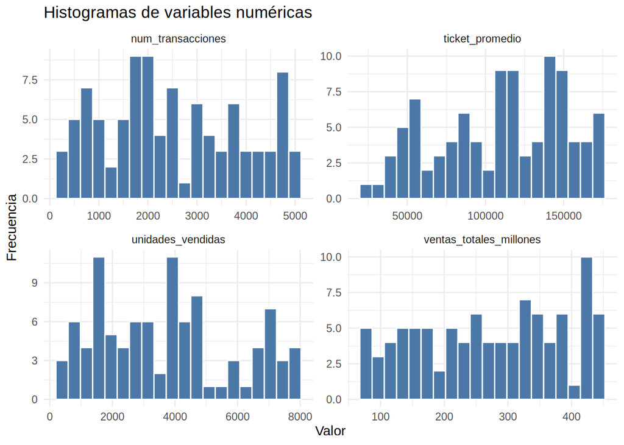

```r
p_hist <- ggplot(long_num, aes(x = valor)) +
  geom_histogram(bins = 20, fill = "#4C78A8", color = "white") +
  facet_wrap(~variable, scales = "free") +
  labs(
    title = "Histogramas de variables numéricas",
    x = "Valor",
    y = "Frecuencia"
  ) +
  theme_minimal()
p_hist
```

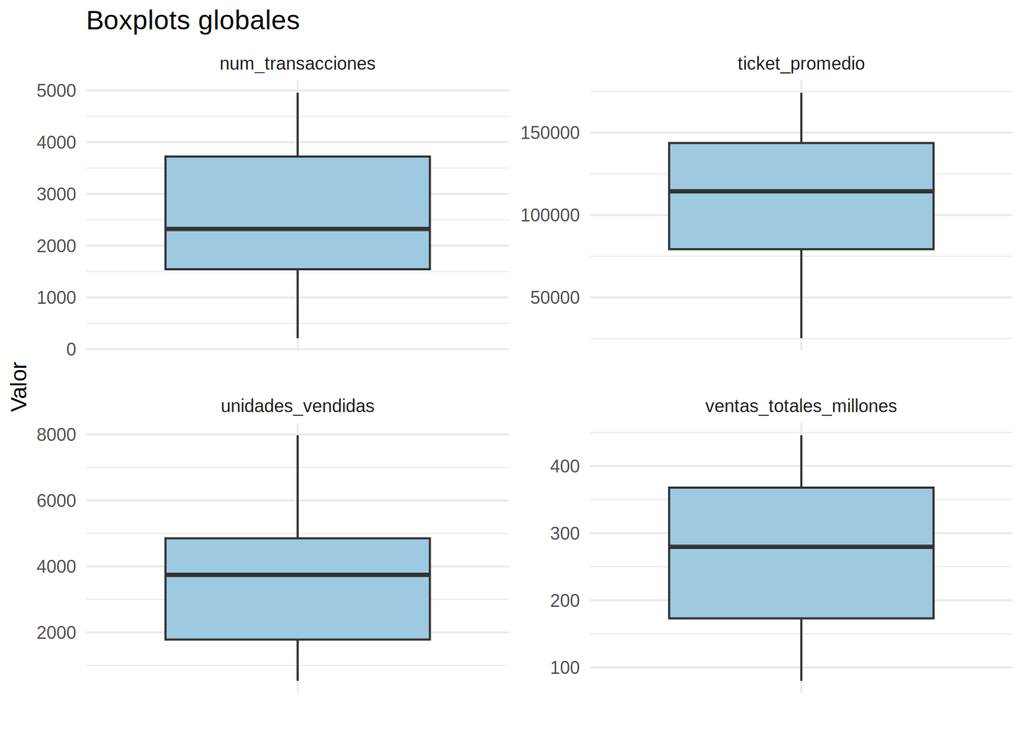

```r
p_box_global <- ggplot(long_num, aes(x = "", y = valor)) +
  geom_boxplot(fill = "#9ecae1") +
  facet_wrap(~variable, scales = "free") +
  labs(
    title = "Boxplots globales",
    x = NULL,
    y = "Valor"
  ) +
  theme_minimal()
p_box_global
```

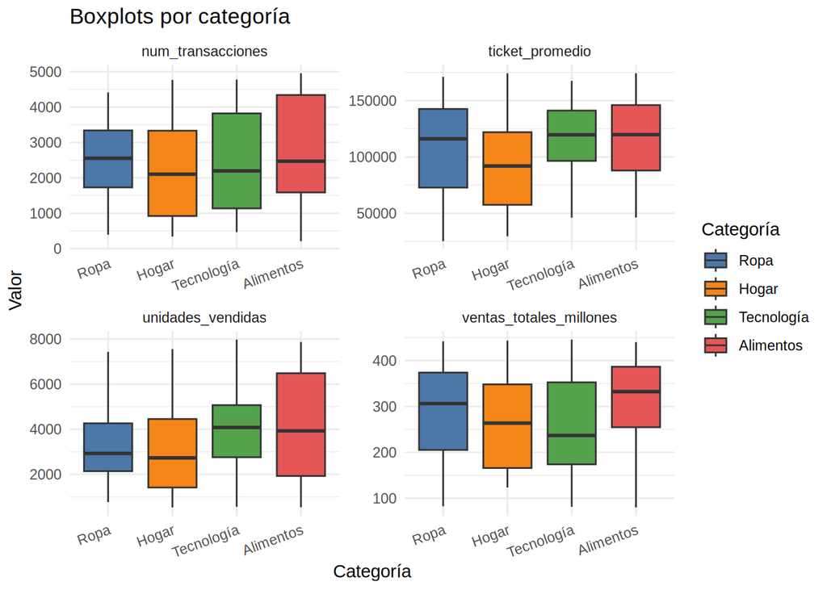

```r
p_box_cat <- ggplot(long_num, aes(x = categoria, y = valor, fill = categoria)) +
  geom_boxplot() +
  facet_wrap(~variable, scales = "free") +
  scale_fill_manual(values = pal_categoria) +
  labs(
    title = "Boxplots por categoría",
    x = "Categoría",
    y = "Valor",
    fill = "Categoría"
  ) +
  theme_minimal() +
  theme(axis.text.x = element_text(angle = 20, hjust = 1))
p_box_cat
```

```r
n_ciudades <- dplyr::n_distinct(retail_clean$ciudad)
if (n_ciudades <= 8) {
  ciudades_boxplot <- as.character(unique(retail_clean$ciudad))
  nota_ciudad <- "Se muestran todas las ciudades."
} else {
  ciudades_boxplot <- retail_clean |>
    dplyr::group_by(ciudad) |>
    dplyr::summarise(ventas = sum(ventas_totales_millones), .groups = "drop") |>
    dplyr::slice_max(ventas, n = 8) |>
    dplyr::pull(ciudad) |>
    as.character()
  nota_ciudad <- paste(
    "Más de 8 ciudades: se muestran las 8 con mayor suma de ventas_totales_millones:",
    paste(ciudades_boxplot, collapse = ", ")
  )
}
cat(nota_ciudad, "\n")
```

```
## Se muestran todas las ciudades.
```

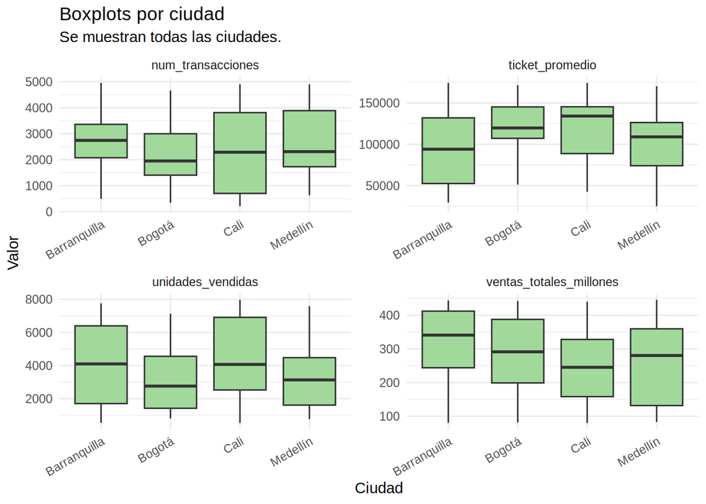

```r
p_box_ciudad <- long_num |>
  dplyr::filter(as.character(ciudad) %in% ciudades_boxplot) |>
  ggplot(aes(x = ciudad, y = valor)) +
  geom_boxplot(fill = "#a1d99b") +
  facet_wrap(~variable, scales = "free") +
  labs(
    title = "Boxplots por ciudad",
    subtitle = nota_ciudad,
    x = "Ciudad",
    y = "Valor"
  ) +
  theme_minimal() +
  theme(axis.text.x = element_text(angle = 30, hjust = 1))
p_box_ciudad
```

# Pairplot

`GGally::ggpairs` de las cuatro numéricas, color por `categoria` (no se omite).

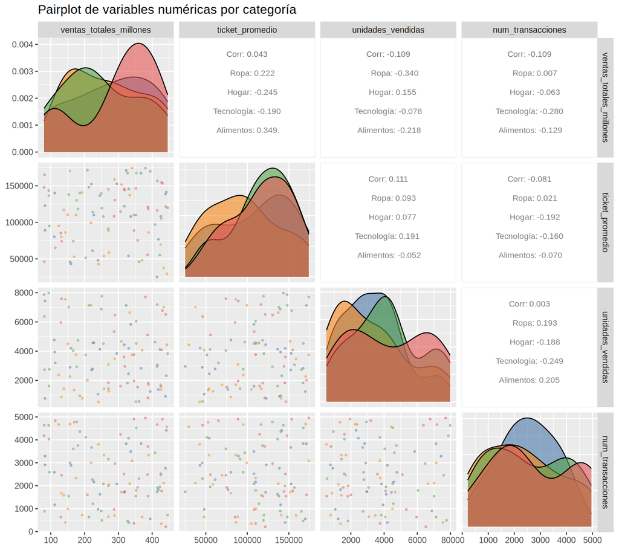

```r
p_pairs <- GGally::ggpairs(
  retail_clean,
  columns = num_cols,
  mapping = ggplot2::aes(color = categoria),
  upper = list(continuous = GGally::wrap("cor", size = 3)),
  lower = list(continuous = GGally::wrap("points", alpha = 0.4, size = 0.7)),
  diag = list(continuous = GGally::wrap("densityDiag", alpha = 0.6))
) +
  ggplot2::scale_color_manual(values = pal_categoria) +
  ggplot2::scale_fill_manual(values = pal_categoria) +
  ggplot2::labs(title = "Pairplot de variables numéricas por categoría")
p_pairs
```

# Correlaciones Pearson y Spearman

Las matrices usan solo las cuatro numéricas (`cor()`, no factores). Los heatmaps son `ggplot2::geom_tile` con la misma escala (−1 a 1). No se ajusta un modelo predictivo: la salida es una recomendación de medida de asociación.

```r
mat_num <- retail_clean |>
  dplyr::select(dplyr::all_of(num_cols)) |>
  as.data.frame()
cor_pearson <- cor(mat_num, method = "pearson", use = "pairwise.complete.obs")
cor_spearman <- cor(mat_num, method = "spearman", use = "pairwise.complete.obs")
stopifnot(isTRUE(all.equal(cor_pearson, t(cor_pearson))))
stopifnot(isTRUE(all.equal(cor_spearman, t(cor_spearman))))
stopifnot(all(abs(diag(cor_pearson) - 1) < 1e-10))
stopifnot(all(abs(diag(cor_spearman) - 1) < 1e-10))
cor_pearson
```

```
##                         ventas_totales_millones ticket_promedio
## ventas_totales_millones              1.00000000      0.04265808
## ticket_promedio                      0.04265808      1.00000000
## unidades_vendidas                   -0.10869289      0.11146134
## num_transacciones                   -0.10902597     -0.08077113
##                         unidades_vendidas num_transacciones
## ventas_totales_millones      -0.108692890      -0.109025968
## ticket_promedio               0.111461343      -0.080771133
## unidades_vendidas             1.000000000       0.002579294
## num_transacciones             0.002579294       1.000000000
```

```r
cor_spearman
```

```
##                         ventas_totales_millones ticket_promedio
## ventas_totales_millones              1.00000000      0.05777481
## ticket_promedio                      0.05777481      1.00000000
## unidades_vendidas                   -0.09721308      0.09885746
## num_transacciones                   -0.09374046     -0.08897510
##                         unidades_vendidas num_transacciones
## ventas_totales_millones      -0.097213085      -0.093740462
## ticket_promedio               0.098857459      -0.088975104
## unidades_vendidas             1.000000000      -0.009827793
## num_transacciones            -0.009827793       1.000000000
```

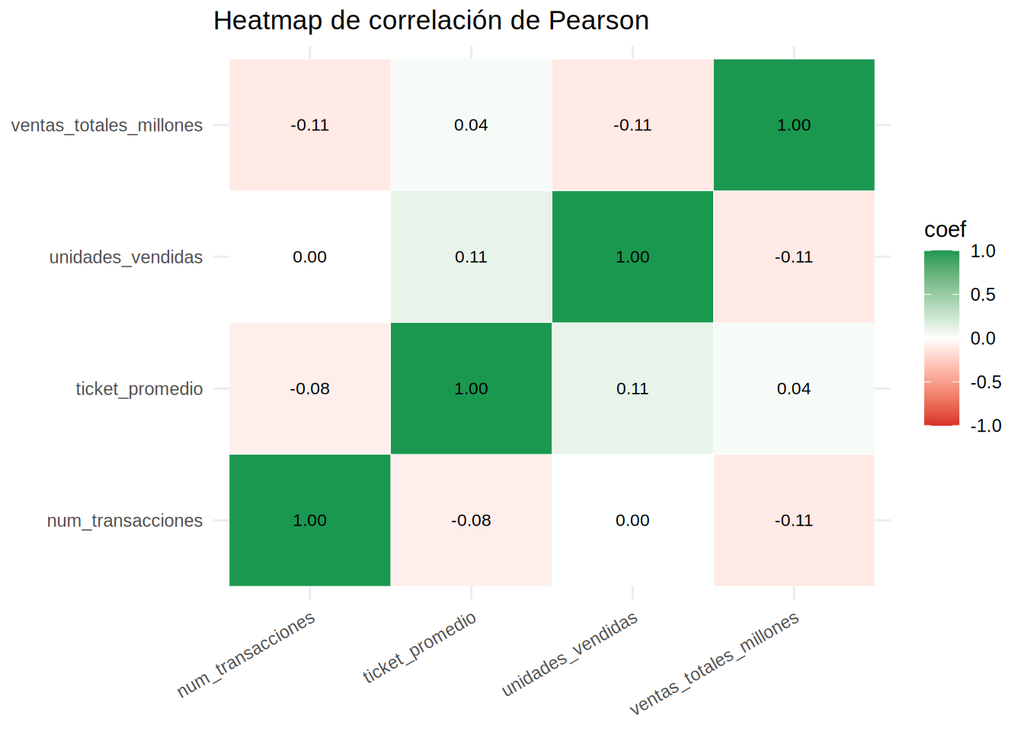

```r
cor_to_long <- function(mat, metodo) {
  as.data.frame(mat) |>
    tibble::rownames_to_column("var1") |>
    tidyr::pivot_longer(-var1, names_to = "var2", values_to = "r") |>
    dplyr::mutate(metodo = metodo)
}

plot_heatmap <- function(df_long, titulo) {
  ggplot(df_long, aes(x = var1, y = var2, fill = r)) +
    geom_tile(color = "white") +
    geom_text(aes(label = sprintf("%.2f", r)), size = 3) +
    scale_fill_gradient2(
      limits = c(-1, 1),
      midpoint = 0,
      low = "#d73027",
      mid = "white",
      high = "#1a9850"
    ) +
    labs(title = titulo, x = NULL, y = NULL, fill = "coef") +
    theme_minimal() +
    theme(axis.text.x = element_text(angle = 30, hjust = 1))
}

p_heat_pearson <- plot_heatmap(
  cor_to_long(cor_pearson, "pearson"),
  "Heatmap de correlación de Pearson"
)
p_heat_spearman <- plot_heatmap(
  cor_to_long(cor_spearman, "spearman"),
  "Heatmap de correlación de Spearman"
)
p_heat_pearson
```

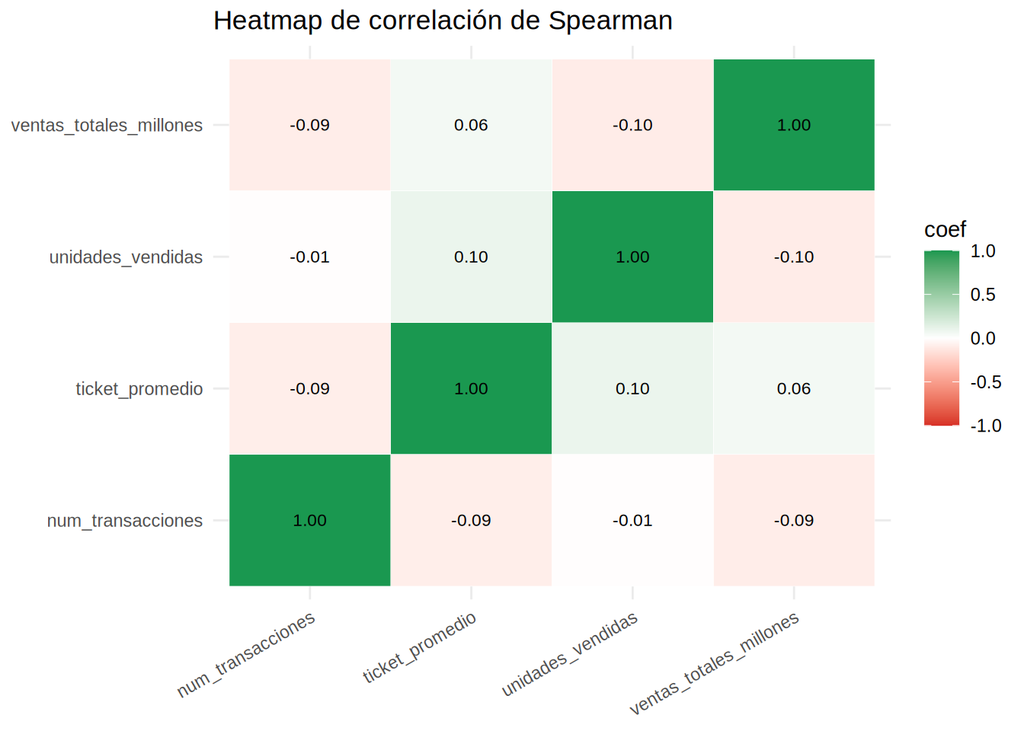

```r
p_heat_spearman
```

```r
idx <- which(upper.tri(cor_pearson), arr.ind = TRUE)
cor_compare <- tibble::tibble(
  par = paste(rownames(cor_pearson)[idx[, 1]],
              colnames(cor_pearson)[idx[, 2]],
              sep = " — "),
  r_pearson = cor_pearson[idx],
  rho_spearman = cor_spearman[idx],
  delta = rho_spearman - r_pearson
) |>
  dplyr::mutate(
    nota = dplyr::case_when(
      abs(delta) < 0.1 ~ "|Δ| < 0.1: Pearson y Spearman coinciden en lo esencial",
      TRUE ~ "|Δ| ≥ 0.1: la asociación lineal y la monótona difieren"
    )
  )
k_delta <- sum(abs(cor_compare$delta) >= 0.1)
off_diag_idx <- which(upper.tri(cor_pearson), arr.ind = TRUE)
max_abs_r_pearson <- max(abs(cor_pearson[off_diag_idx]))
cor_compare
```

| par | r_pearson | rho_spearman | delta | nota |
| --- | --- | --- | --- | --- |
| ventas_totales_millones — ticket_promedio | 0.042658082 | 0.057774809 | 0.015116727 | \|Δ\| < 0.1: Pearson y Spearman coinciden en lo esencial |
| ventas_totales_millones — unidades_vendidas | -0.108692890 | -0.097213085 | 0.011479805 | \|Δ\| < 0.1: Pearson y Spearman coinciden en lo esencial |
| ticket_promedio — unidades_vendidas | 0.111461343 | 0.098857459 | -0.012603884 | \|Δ\| < 0.1: Pearson y Spearman coinciden en lo esencial |
| ventas_totales_millones — num_transacciones | -0.109025968 | -0.093740462 | 0.015285506 | \|Δ\| < 0.1: Pearson y Spearman coinciden en lo esencial |
| ticket_promedio — num_transacciones | -0.080771133 | -0.088975104 | -0.008203971 | \|Δ\| < 0.1: Pearson y Spearman coinciden en lo esencial |
| unidades_vendidas — num_transacciones | 0.002579294 | -0.009827793 | -0.012407087 | \|Δ\| < 0.1: Pearson y Spearman coinciden en lo esencial |

```r
cat("Pares con |delta| >= 0.1 (k) =", k_delta, "\n")
```

```
## Pares con |delta| >= 0.1 (k) = 0
```

```r
cat("max(abs(r_pearson)) fuera de diagonal =", round(max_abs_r_pearson, 3), "\n")
```

```
## max(abs(r_pearson)) fuera de diagonal = 0.111
```

Tras inspeccionar el pairplot, `curvatura_evidente` permanece `FALSE` salvo que haya curvatura evidente en las relaciones entre numéricas.

```r
# Tras ver el pairplot: TRUE si hay curvatura o relación monótona no lineal evidente.
curvatura_evidente <- FALSE

if (isTRUE(curvatura_evidente)) {
  recomendacion <- "Spearman"
  motivo <- "El pairplot muestra curvatura o monotonía no lineal; Spearman describe mejor la asociación."
} else if (k_delta == 0) {
  recomendacion <- "Pearson"
  motivo <- "k = 0 y sin curvatura evidente: un modelo lineal posterior es razonable."
  if (max_abs_r_pearson < 0.3) {
    motivo <- paste0(
      motivo,
      " Las asociaciones son débiles (max |r| < 0.3); Pearson es la recomendación por el criterio Δ, ",
      "pero un modelo lineal tendría poco que explicar."
    )
  }
} else if (k_delta >= 3) {
  recomendacion <- "Spearman"
  motivo <- paste0(
    "k = ", k_delta,
    " pares con |Δ| ≥ 0.1: Spearman es la medida principal; un lineal puede engañar."
  )
} else {
  recomendacion <- "mixto"
  motivo <- paste0(
    "k = ", k_delta,
    " (1 o 2 pares). No hay un único ganador; revisar esos pares en la tabla."
  )
}
cat("Recomendación:", recomendacion, "\n")
```

```
## Recomendación: Pearson
```

```r
cat(motivo, "\n")
```

```
## k = 0 y sin curvatura evidente: un modelo lineal posterior es razonable. Las asociaciones son débiles (max |r| < 0.3); Pearson es la recomendación por el criterio Δ, pero un modelo lineal tendría poco que explicar.
```

La recomendación es una **medida de asociación**, no un modelo ajustado. El umbral 0.1 es una guía de lectura, no un test de hipótesis.